# ch08_sonar_analysis01

### 분류(classification) 문제 실습 - 항구의 기뢰 찾기

### 학습 목표

- urlopen를 이용하여 웹에서의 데이터를 가져오는 것을 실습해 본다.
- pandas를 이용하여 웹에서의 데이터를 가져오는 것을 실습해 본다.
- 데이터를 가져오고 이를 시각화를 통해 데이터를 이해해 본다.

### 학습 내용

- 웹에서의 데이터를 가져와 보기
- 웹의 데이터를 Pandas를 이용해 가져와 보기
- 데이터 인사이트를 확인하기 위한 데이터 시각화
- 데이터 셋 : UC Irvine Data Repository
  - https://archive.ics.uci.edu/ml/datasets.php
  - Connectionist Bench (Sonar, Mines vs. Rocks) Data Set
    - https://archive.ics.uci.edu/ml/datasets/Connectionist+Bench+%28Sonar%2C+Mines+vs.+Rocks%29
    - sonar.all-data

### 데이터 설명

- 데이터 셋 특성 : 다변수
- 행의 수 : 208개
- 열의 수 : 60개
- 데이터 설명
  - 다양한 각도와 다양한 조건에서 금속 실린더에서 수중 음파 탐지기 신호를 통해 얻은 다양한 패턴이 포함되어 있음.
  - 군사작전의 결과로 항구에 남아 있는 폭파되지 않은 기뢰를 찾기 위해 소나(Sonar, 수중 음파탐지기)를 이용할 수 있는지 확인하기 위한 어떤 실험으로 만들어짐.
  - 반 정도의 표본은 바위, 나마저 반은 기뢰 모양의 금속 원통을 나타냄.

### 01. 데이터 준비

```python
from urllib.request import urlopen
import sys
```

```python
target_url = "https://archive.ics.uci.edu/ml/machine-learning-databases/undocumented/connectionist-bench/sonar/sonar.all-data"
data = urlopen(target_url)
data
```

```
<http.client.HTTPResponse at 0x7fbe0745ddf0>
```

### 레이블을 리스트로, 속성을 리스트의 리스트로 확인

```python
list_dat = []
labels = []
for line in data:
    #print(line)
    # 쉼표로 분리
    line = str(line)
    row = line.strip().split(",")
    list_dat.append(row)
```

```python
len(list_dat), list_dat[0]
```

```
(207,
 ["b'0.0453",
  '0.0523',
  '0.0843',
  '0.0689',
  '0.1183',
  '0.2583',
  '0.2156',
  '0.3481',
  '0.3337',
  '0.2872',
  '0.4918',
  '0.6552',
  '0.6919',
  '0.7797',
  '0.7464',
  '0.9444',
  '1.0000',
  '0.8874',
  '0.8024',
  '0.7818',
  '0.5212',
  '0.4052',
  '0.3957',
  '0.3914',
  '0.3250',
  '0.3200',
  '0.3271',
  '0.2767',
  '0.4423',
  '0.2028',
  '0.3788',
  '0.2947',
  '0.1984',
  '0.2341',
  '0.1306',
  '0.4182',
  '0.3835',
  '0.1057',
  '0.1840',
  '0.1970',
  '0.1674',
  '0.0583',
  '0.1401',
  '0.1628',
  '0.0621',
  '0.0203',
  '0.0530',
  '0.0742',
  '0.0409',
  '0.0061',
  '0.0125',
  '0.0084',
  '0.0089',
  '0.0048',
  '0.0094',
  '0.0191',
  '0.0140',
  '0.0049',
  '0.0052',
  '0.0044',
  "R\\n'"])
```

### 01. 데이터 준비 - pandas의 활용

```python
import matplotlib.pyplot as plt
import pandas as pd
```

```python
target_url = "https://archive.ics.uci.edu/ml/machine-learning-databases/undocumented/connectionist-bench/sonar/sonar.all-data"
rocksVMines = pd.read_csv(target_url, header=None, prefix='V')
rocksVMines
```

|  | V0 | V1 | V2 | V3 | V4 | V5 | V6 | V7 | V8 | V9 | V10 | V11 | V12 | V13 | V14 | V15 | V16 | V17 | V18 | V19 | V20 | V21 | V22 | V23 | V24 | V25 | V26 | V27 | V28 | … |
| --- | --- | --- | --- | --- | --- | --- | --- | --- | --- | --- | --- | --- | --- | --- | --- | --- | --- | --- | --- | --- | --- | --- | --- | --- | --- | --- | --- | --- | --- | --- |
| 0 | 0.0200 | 0.0371 | 0.0428 | 0.0207 | 0.0954 | 0.0986 | 0.1539 | 0.1601 | 0.3109 | 0.2111 | 0.1609 | 0.1582 | 0.2238 | 0.0645 | 0.0660 | 0.2273 | 0.3100 | 0.2999 | 0.5078 | 0.4797 | 0.5783 | 0.5071 | 0.4328 | 0.5550 | 0.6711 | 0.6415 | 0.7104 | 0.8080 | 0.6791 | … |
| 1 | 0.0453 | 0.0523 | 0.0843 | 0.0689 | 0.1183 | 0.2583 | 0.2156 | 0.3481 | 0.3337 | 0.2872 | 0.4918 | 0.6552 | 0.6919 | 0.7797 | 0.7464 | 0.9444 | 1.0000 | 0.8874 | 0.8024 | 0.7818 | 0.5212 | 0.4052 | 0.3957 | 0.3914 | 0.3250 | 0.3200 | 0.3271 | 0.2767 | 0.4423 | … |
| 2 | 0.0262 | 0.0582 | 0.1099 | 0.1083 | 0.0974 | 0.2280 | 0.2431 | 0.3771 | 0.5598 | 0.6194 | 0.6333 | 0.7060 | 0.5544 | 0.5320 | 0.6479 | 0.6931 | 0.6759 | 0.7551 | 0.8929 | 0.8619 | 0.7974 | 0.6737 | 0.4293 | 0.3648 | 0.5331 | 0.2413 | 0.5070 | 0.8533 | 0.6036 | … |
| 3 | 0.0100 | 0.0171 | 0.0623 | 0.0205 | 0.0205 | 0.0368 | 0.1098 | 0.1276 | 0.0598 | 0.1264 | 0.0881 | 0.1992 | 0.0184 | 0.2261 | 0.1729 | 0.2131 | 0.0693 | 0.2281 | 0.4060 | 0.3973 | 0.2741 | 0.3690 | 0.5556 | 0.4846 | 0.3140 | 0.5334 | 0.5256 | 0.2520 | 0.2090 | … |
| 4 | 0.0762 | 0.0666 | 0.0481 | 0.0394 | 0.0590 | 0.0649 | 0.1209 | 0.2467 | 0.3564 | 0.4459 | 0.4152 | 0.3952 | 0.4256 | 0.4135 | 0.4528 | 0.5326 | 0.7306 | 0.6193 | 0.2032 | 0.4636 | 0.4148 | 0.4292 | 0.5730 | 0.5399 | 0.3161 | 0.2285 | 0.6995 | 1.0000 | 0.7262 | … |
| 5 | 0.0286 | 0.0453 | 0.0277 | 0.0174 | 0.0384 | 0.0990 | 0.1201 | 0.1833 | 0.2105 | 0.3039 | 0.2988 | 0.4250 | 0.6343 | 0.8198 | 1.0000 | 0.9988 | 0.9508 | 0.9025 | 0.7234 | 0.5122 | 0.2074 | 0.3985 | 0.5890 | 0.2872 | 0.2043 | 0.5782 | 0.5389 | 0.3750 | 0.3411 | … |
| 6 | 0.0317 | 0.0956 | 0.1321 | 0.1408 | 0.1674 | 0.1710 | 0.0731 | 0.1401 | 0.2083 | 0.3513 | 0.1786 | 0.0658 | 0.0513 | 0.3752 | 0.5419 | 0.5440 | 0.5150 | 0.4262 | 0.2024 | 0.4233 | 0.7723 | 0.9735 | 0.9390 | 0.5559 | 0.5268 | 0.6826 | 0.5713 | 0.5429 | 0.2177 | … |
| 7 | 0.0519 | 0.0548 | 0.0842 | 0.0319 | 0.1158 | 0.0922 | 0.1027 | 0.0613 | 0.1465 | 0.2838 | 0.2802 | 0.3086 | 0.2657 | 0.3801 | 0.5626 | 0.4376 | 0.2617 | 0.1199 | 0.6676 | 0.9402 | 0.7832 | 0.5352 | 0.6809 | 0.9174 | 0.7613 | 0.8220 | 0.8872 | 0.6091 | 0.2967 | … |
| 8 | 0.0223 | 0.0375 | 0.0484 | 0.0475 | 0.0647 | 0.0591 | 0.0753 | 0.0098 | 0.0684 | 0.1487 | 0.1156 | 0.1654 | 0.3833 | 0.3598 | 0.1713 | 0.1136 | 0.0349 | 0.3796 | 0.7401 | 0.9925 | 0.9802 | 0.8890 | 0.6712 | 0.4286 | 0.3374 | 0.7366 | 0.9611 | 0.7353 | 0.4856 | … |
| 9 | 0.0164 | 0.0173 | 0.0347 | 0.0070 | 0.0187 | 0.0671 | 0.1056 | 0.0697 | 0.0962 | 0.0251 | 0.0801 | 0.1056 | 0.1266 | 0.0890 | 0.0198 | 0.1133 | 0.2826 | 0.3234 | 0.3238 | 0.4333 | 0.6068 | 0.7652 | 0.9203 | 0.9719 | 0.9207 | 0.7545 | 0.8289 | 0.8907 | 0.7309 | … |
| 10 | 0.0039 | 0.0063 | 0.0152 | 0.0336 | 0.0310 | 0.0284 | 0.0396 | 0.0272 | 0.0323 | 0.0452 | 0.0492 | 0.0996 | 0.1424 | 0.1194 | 0.0628 | 0.0907 | 0.1177 | 0.1429 | 0.1223 | 0.1104 | 0.1847 | 0.3715 | 0.4382 | 0.5707 | 0.6654 | 0.7476 | 0.7654 | 0.8555 | 0.9720 | … |
| 11 | 0.0123 | 0.0309 | 0.0169 | 0.0313 | 0.0358 | 0.0102 | 0.0182 | 0.0579 | 0.1122 | 0.0835 | 0.0548 | 0.0847 | 0.2026 | 0.2557 | 0.1870 | 0.2032 | 0.1463 | 0.2849 | 0.5824 | 0.7728 | 0.7852 | 0.8515 | 0.5312 | 0.3653 | 0.5973 | 0.8275 | 1.0000 | 0.8673 | 0.6301 | … |
| 12 | 0.0079 | 0.0086 | 0.0055 | 0.0250 | 0.0344 | 0.0546 | 0.0528 | 0.0958 | 0.1009 | 0.1240 | 0.1097 | 0.1215 | 0.1874 | 0.3383 | 0.3227 | 0.2723 | 0.3943 | 0.6432 | 0.7271 | 0.8673 | 0.9674 | 0.9847 | 0.9480 | 0.8036 | 0.6833 | 0.5136 | 0.3090 | 0.0832 | 0.4019 | … |
| 13 | 0.0090 | 0.0062 | 0.0253 | 0.0489 | 0.1197 | 0.1589 | 0.1392 | 0.0987 | 0.0955 | 0.1895 | 0.1896 | 0.2547 | 0.4073 | 0.2988 | 0.2901 | 0.5326 | 0.4022 | 0.1571 | 0.3024 | 0.3907 | 0.3542 | 0.4438 | 0.6414 | 0.4601 | 0.6009 | 0.8690 | 0.8345 | 0.7669 | 0.5081 | … |
| 14 | 0.0124 | 0.0433 | 0.0604 | 0.0449 | 0.0597 | 0.0355 | 0.0531 | 0.0343 | 0.1052 | 0.2120 | 0.1640 | 0.1901 | 0.3026 | 0.2019 | 0.0592 | 0.2390 | 0.3657 | 0.3809 | 0.5929 | 0.6299 | 0.5801 | 0.4574 | 0.4449 | 0.3691 | 0.6446 | 0.8940 | 0.8978 | 0.4980 | 0.3333 | … |
| 15 | 0.0298 | 0.0615 | 0.0650 | 0.0921 | 0.1615 | 0.2294 | 0.2176 | 0.2033 | 0.1459 | 0.0852 | 0.2476 | 0.3645 | 0.2777 | 0.2826 | 0.3237 | 0.4335 | 0.5638 | 0.4555 | 0.4348 | 0.6433 | 0.3932 | 0.1989 | 0.3540 | 0.9165 | 0.9371 | 0.4620 | 0.2771 | 0.6613 | 0.8028 | … |
| 16 | 0.0352 | 0.0116 | 0.0191 | 0.0469 | 0.0737 | 0.1185 | 0.1683 | 0.1541 | 0.1466 | 0.2912 | 0.2328 | 0.2237 | 0.2470 | 0.1560 | 0.3491 | 0.3308 | 0.2299 | 0.2203 | 0.2493 | 0.4128 | 0.3158 | 0.6191 | 0.5854 | 0.3395 | 0.2561 | 0.5599 | 0.8145 | 0.6941 | 0.6985 | … |
| 17 | 0.0192 | 0.0607 | 0.0378 | 0.0774 | 0.1388 | 0.0809 | 0.0568 | 0.0219 | 0.1037 | 0.1186 | 0.1237 | 0.1601 | 0.3520 | 0.4479 | 0.3769 | 0.5761 | 0.6426 | 0.6790 | 0.7157 | 0.5466 | 0.5399 | 0.6362 | 0.7849 | 0.7756 | 0.5780 | 0.4862 | 0.4181 | 0.2457 | 0.0716 | … |
| 18 | 0.0270 | 0.0092 | 0.0145 | 0.0278 | 0.0412 | 0.0757 | 0.1026 | 0.1138 | 0.0794 | 0.1520 | 0.1675 | 0.1370 | 0.1361 | 0.1345 | 0.2144 | 0.5354 | 0.6830 | 0.5600 | 0.3093 | 0.3226 | 0.4430 | 0.5573 | 0.5782 | 0.6173 | 0.8132 | 0.9819 | 0.9823 | 0.9166 | 0.7423 | … |
| 19 | 0.0126 | 0.0149 | 0.0641 | 0.1732 | 0.2565 | 0.2559 | 0.2947 | 0.4110 | 0.4983 | 0.5920 | 0.5832 | 0.5419 | 0.5472 | 0.5314 | 0.4981 | 0.6985 | 0.8292 | 0.7839 | 0.8215 | 0.9363 | 1.0000 | 0.9224 | 0.7839 | 0.5470 | 0.4562 | 0.5922 | 0.5448 | 0.3971 | 0.0882 | … |
| 20 | 0.0473 | 0.0509 | 0.0819 | 0.1252 | 0.1783 | 0.3070 | 0.3008 | 0.2362 | 0.3830 | 0.3759 | 0.3021 | 0.2909 | 0.2301 | 0.1411 | 0.1582 | 0.2430 | 0.4474 | 0.5964 | 0.6744 | 0.7969 | 0.8319 | 0.7813 | 0.8626 | 0.7369 | 0.4122 | 0.2596 | 0.3392 | 0.3788 | 0.4488 | … |
| 21 | 0.0664 | 0.0575 | 0.0842 | 0.0372 | 0.0458 | 0.0771 | 0.0771 | 0.1130 | 0.2353 | 0.1838 | 0.2869 | 0.4129 | 0.3647 | 0.1984 | 0.2840 | 0.4039 | 0.5837 | 0.6792 | 0.6086 | 0.4858 | 0.3246 | 0.2013 | 0.2082 | 0.1686 | 0.2484 | 0.2736 | 0.2984 | 0.4655 | 0.6990 | … |
| 22 | 0.0099 | 0.0484 | 0.0299 | 0.0297 | 0.0652 | 0.1077 | 0.2363 | 0.2385 | 0.0075 | 0.1882 | 0.1456 | 0.1892 | 0.3176 | 0.1340 | 0.2169 | 0.2458 | 0.2589 | 0.2786 | 0.2298 | 0.0656 | 0.1441 | 0.1179 | 0.1668 | 0.1783 | 0.2476 | 0.2570 | 0.1036 | 0.5356 | 0.7124 | … |
| 23 | 0.0115 | 0.0150 | 0.0136 | 0.0076 | 0.0211 | 0.1058 | 0.1023 | 0.0440 | 0.0931 | 0.0734 | 0.0740 | 0.0622 | 0.1055 | 0.1183 | 0.1721 | 0.2584 | 0.3232 | 0.3817 | 0.4243 | 0.4217 | 0.4449 | 0.4075 | 0.3306 | 0.4012 | 0.4466 | 0.5218 | 0.7552 | 0.9503 | 1.0000 | … |
| 24 | 0.0293 | 0.0644 | 0.0390 | 0.0173 | 0.0476 | 0.0816 | 0.0993 | 0.0315 | 0.0736 | 0.0860 | 0.0414 | 0.0472 | 0.0835 | 0.0938 | 0.1466 | 0.0809 | 0.1179 | 0.2179 | 0.3326 | 0.3258 | 0.2111 | 0.2302 | 0.3361 | 0.4259 | 0.4609 | 0.2606 | 0.0874 | 0.2862 | 0.5606 | … |
| 25 | 0.0201 | 0.0026 | 0.0138 | 0.0062 | 0.0133 | 0.0151 | 0.0541 | 0.0210 | 0.0505 | 0.1097 | 0.0841 | 0.0942 | 0.1204 | 0.0420 | 0.0031 | 0.0162 | 0.0624 | 0.2127 | 0.3436 | 0.3813 | 0.3825 | 0.4764 | 0.6313 | 0.7523 | 0.8675 | 0.8788 | 0.7901 | 0.8357 | 0.9631 | … |
| 26 | 0.0151 | 0.0320 | 0.0599 | 0.1050 | 0.1163 | 0.1734 | 0.1679 | 0.1119 | 0.0889 | 0.1205 | 0.0847 | 0.1518 | 0.2305 | 0.2793 | 0.3404 | 0.4527 | 0.6950 | 0.8807 | 0.9154 | 0.7542 | 0.6736 | 0.7146 | 0.8335 | 0.7701 | 0.6993 | 0.6543 | 0.5040 | 0.4926 | 0.4992 | … |
| 27 | 0.0177 | 0.0300 | 0.0288 | 0.0394 | 0.0630 | 0.0526 | 0.0688 | 0.0633 | 0.0624 | 0.0613 | 0.1680 | 0.3476 | 0.4561 | 0.5188 | 0.6308 | 0.7201 | 0.5153 | 0.3818 | 0.2644 | 0.3345 | 0.4865 | 0.6628 | 0.7389 | 0.9213 | 1.0000 | 0.7750 | 0.5593 | 0.6172 | 0.8635 | … |
| 28 | 0.0100 | 0.0275 | 0.0190 | 0.0371 | 0.0416 | 0.0201 | 0.0314 | 0.0651 | 0.1896 | 0.2668 | 0.3376 | 0.3282 | 0.2432 | 0.1268 | 0.1278 | 0.4441 | 0.6795 | 0.7051 | 0.7966 | 0.9401 | 0.9857 | 0.8193 | 0.5789 | 0.6394 | 0.7043 | 0.6875 | 0.4081 | 0.1811 | 0.2064 | … |
| 29 | 0.0189 | 0.0308 | 0.0197 | 0.0622 | 0.0080 | 0.0789 | 0.1440 | 0.1451 | 0.1789 | 0.2522 | 0.2607 | 0.3710 | 0.3906 | 0.2672 | 0.2716 | 0.4183 | 0.6988 | 0.5733 | 0.2226 | 0.2631 | 0.7473 | 0.7263 | 0.3393 | 0.2824 | 0.6053 | 0.5897 | 0.4967 | 0.8616 | 0.8339 | … |

[output cut: 178 more lines]

```python
### 보이지 않는 행과 열 보기
pd.set_option('display.max_columns', None)
pd.set_option('display.max_rows', None)
```

```python
rocksVMines
```

|  | V0 | V1 | V2 | V3 | V4 | V5 | V6 | V7 | V8 | V9 | V10 | V11 | V12 | V13 | V14 | V15 | V16 | V17 | V18 | V19 | V20 | V21 | V22 | V23 | V24 | V25 | V26 | V27 | V28 | … |
| --- | --- | --- | --- | --- | --- | --- | --- | --- | --- | --- | --- | --- | --- | --- | --- | --- | --- | --- | --- | --- | --- | --- | --- | --- | --- | --- | --- | --- | --- | --- |
| 0 | 0.0200 | 0.0371 | 0.0428 | 0.0207 | 0.0954 | 0.0986 | 0.1539 | 0.1601 | 0.3109 | 0.2111 | 0.1609 | 0.1582 | 0.2238 | 0.0645 | 0.0660 | 0.2273 | 0.3100 | 0.2999 | 0.5078 | 0.4797 | 0.5783 | 0.5071 | 0.4328 | 0.5550 | 0.6711 | 0.6415 | 0.7104 | 0.8080 | 0.6791 | … |
| 1 | 0.0453 | 0.0523 | 0.0843 | 0.0689 | 0.1183 | 0.2583 | 0.2156 | 0.3481 | 0.3337 | 0.2872 | 0.4918 | 0.6552 | 0.6919 | 0.7797 | 0.7464 | 0.9444 | 1.0000 | 0.8874 | 0.8024 | 0.7818 | 0.5212 | 0.4052 | 0.3957 | 0.3914 | 0.3250 | 0.3200 | 0.3271 | 0.2767 | 0.4423 | … |
| 2 | 0.0262 | 0.0582 | 0.1099 | 0.1083 | 0.0974 | 0.2280 | 0.2431 | 0.3771 | 0.5598 | 0.6194 | 0.6333 | 0.7060 | 0.5544 | 0.5320 | 0.6479 | 0.6931 | 0.6759 | 0.7551 | 0.8929 | 0.8619 | 0.7974 | 0.6737 | 0.4293 | 0.3648 | 0.5331 | 0.2413 | 0.5070 | 0.8533 | 0.6036 | … |
| 3 | 0.0100 | 0.0171 | 0.0623 | 0.0205 | 0.0205 | 0.0368 | 0.1098 | 0.1276 | 0.0598 | 0.1264 | 0.0881 | 0.1992 | 0.0184 | 0.2261 | 0.1729 | 0.2131 | 0.0693 | 0.2281 | 0.4060 | 0.3973 | 0.2741 | 0.3690 | 0.5556 | 0.4846 | 0.3140 | 0.5334 | 0.5256 | 0.2520 | 0.2090 | … |
| 4 | 0.0762 | 0.0666 | 0.0481 | 0.0394 | 0.0590 | 0.0649 | 0.1209 | 0.2467 | 0.3564 | 0.4459 | 0.4152 | 0.3952 | 0.4256 | 0.4135 | 0.4528 | 0.5326 | 0.7306 | 0.6193 | 0.2032 | 0.4636 | 0.4148 | 0.4292 | 0.5730 | 0.5399 | 0.3161 | 0.2285 | 0.6995 | 1.0000 | 0.7262 | … |
| 5 | 0.0286 | 0.0453 | 0.0277 | 0.0174 | 0.0384 | 0.0990 | 0.1201 | 0.1833 | 0.2105 | 0.3039 | 0.2988 | 0.4250 | 0.6343 | 0.8198 | 1.0000 | 0.9988 | 0.9508 | 0.9025 | 0.7234 | 0.5122 | 0.2074 | 0.3985 | 0.5890 | 0.2872 | 0.2043 | 0.5782 | 0.5389 | 0.3750 | 0.3411 | … |
| 6 | 0.0317 | 0.0956 | 0.1321 | 0.1408 | 0.1674 | 0.1710 | 0.0731 | 0.1401 | 0.2083 | 0.3513 | 0.1786 | 0.0658 | 0.0513 | 0.3752 | 0.5419 | 0.5440 | 0.5150 | 0.4262 | 0.2024 | 0.4233 | 0.7723 | 0.9735 | 0.9390 | 0.5559 | 0.5268 | 0.6826 | 0.5713 | 0.5429 | 0.2177 | … |
| 7 | 0.0519 | 0.0548 | 0.0842 | 0.0319 | 0.1158 | 0.0922 | 0.1027 | 0.0613 | 0.1465 | 0.2838 | 0.2802 | 0.3086 | 0.2657 | 0.3801 | 0.5626 | 0.4376 | 0.2617 | 0.1199 | 0.6676 | 0.9402 | 0.7832 | 0.5352 | 0.6809 | 0.9174 | 0.7613 | 0.8220 | 0.8872 | 0.6091 | 0.2967 | … |
| 8 | 0.0223 | 0.0375 | 0.0484 | 0.0475 | 0.0647 | 0.0591 | 0.0753 | 0.0098 | 0.0684 | 0.1487 | 0.1156 | 0.1654 | 0.3833 | 0.3598 | 0.1713 | 0.1136 | 0.0349 | 0.3796 | 0.7401 | 0.9925 | 0.9802 | 0.8890 | 0.6712 | 0.4286 | 0.3374 | 0.7366 | 0.9611 | 0.7353 | 0.4856 | … |
| 9 | 0.0164 | 0.0173 | 0.0347 | 0.0070 | 0.0187 | 0.0671 | 0.1056 | 0.0697 | 0.0962 | 0.0251 | 0.0801 | 0.1056 | 0.1266 | 0.0890 | 0.0198 | 0.1133 | 0.2826 | 0.3234 | 0.3238 | 0.4333 | 0.6068 | 0.7652 | 0.9203 | 0.9719 | 0.9207 | 0.7545 | 0.8289 | 0.8907 | 0.7309 | … |
| 10 | 0.0039 | 0.0063 | 0.0152 | 0.0336 | 0.0310 | 0.0284 | 0.0396 | 0.0272 | 0.0323 | 0.0452 | 0.0492 | 0.0996 | 0.1424 | 0.1194 | 0.0628 | 0.0907 | 0.1177 | 0.1429 | 0.1223 | 0.1104 | 0.1847 | 0.3715 | 0.4382 | 0.5707 | 0.6654 | 0.7476 | 0.7654 | 0.8555 | 0.9720 | … |
| 11 | 0.0123 | 0.0309 | 0.0169 | 0.0313 | 0.0358 | 0.0102 | 0.0182 | 0.0579 | 0.1122 | 0.0835 | 0.0548 | 0.0847 | 0.2026 | 0.2557 | 0.1870 | 0.2032 | 0.1463 | 0.2849 | 0.5824 | 0.7728 | 0.7852 | 0.8515 | 0.5312 | 0.3653 | 0.5973 | 0.8275 | 1.0000 | 0.8673 | 0.6301 | … |
| 12 | 0.0079 | 0.0086 | 0.0055 | 0.0250 | 0.0344 | 0.0546 | 0.0528 | 0.0958 | 0.1009 | 0.1240 | 0.1097 | 0.1215 | 0.1874 | 0.3383 | 0.3227 | 0.2723 | 0.3943 | 0.6432 | 0.7271 | 0.8673 | 0.9674 | 0.9847 | 0.9480 | 0.8036 | 0.6833 | 0.5136 | 0.3090 | 0.0832 | 0.4019 | … |
| 13 | 0.0090 | 0.0062 | 0.0253 | 0.0489 | 0.1197 | 0.1589 | 0.1392 | 0.0987 | 0.0955 | 0.1895 | 0.1896 | 0.2547 | 0.4073 | 0.2988 | 0.2901 | 0.5326 | 0.4022 | 0.1571 | 0.3024 | 0.3907 | 0.3542 | 0.4438 | 0.6414 | 0.4601 | 0.6009 | 0.8690 | 0.8345 | 0.7669 | 0.5081 | … |
| 14 | 0.0124 | 0.0433 | 0.0604 | 0.0449 | 0.0597 | 0.0355 | 0.0531 | 0.0343 | 0.1052 | 0.2120 | 0.1640 | 0.1901 | 0.3026 | 0.2019 | 0.0592 | 0.2390 | 0.3657 | 0.3809 | 0.5929 | 0.6299 | 0.5801 | 0.4574 | 0.4449 | 0.3691 | 0.6446 | 0.8940 | 0.8978 | 0.4980 | 0.3333 | … |
| 15 | 0.0298 | 0.0615 | 0.0650 | 0.0921 | 0.1615 | 0.2294 | 0.2176 | 0.2033 | 0.1459 | 0.0852 | 0.2476 | 0.3645 | 0.2777 | 0.2826 | 0.3237 | 0.4335 | 0.5638 | 0.4555 | 0.4348 | 0.6433 | 0.3932 | 0.1989 | 0.3540 | 0.9165 | 0.9371 | 0.4620 | 0.2771 | 0.6613 | 0.8028 | … |
| 16 | 0.0352 | 0.0116 | 0.0191 | 0.0469 | 0.0737 | 0.1185 | 0.1683 | 0.1541 | 0.1466 | 0.2912 | 0.2328 | 0.2237 | 0.2470 | 0.1560 | 0.3491 | 0.3308 | 0.2299 | 0.2203 | 0.2493 | 0.4128 | 0.3158 | 0.6191 | 0.5854 | 0.3395 | 0.2561 | 0.5599 | 0.8145 | 0.6941 | 0.6985 | … |
| 17 | 0.0192 | 0.0607 | 0.0378 | 0.0774 | 0.1388 | 0.0809 | 0.0568 | 0.0219 | 0.1037 | 0.1186 | 0.1237 | 0.1601 | 0.3520 | 0.4479 | 0.3769 | 0.5761 | 0.6426 | 0.6790 | 0.7157 | 0.5466 | 0.5399 | 0.6362 | 0.7849 | 0.7756 | 0.5780 | 0.4862 | 0.4181 | 0.2457 | 0.0716 | … |
| 18 | 0.0270 | 0.0092 | 0.0145 | 0.0278 | 0.0412 | 0.0757 | 0.1026 | 0.1138 | 0.0794 | 0.1520 | 0.1675 | 0.1370 | 0.1361 | 0.1345 | 0.2144 | 0.5354 | 0.6830 | 0.5600 | 0.3093 | 0.3226 | 0.4430 | 0.5573 | 0.5782 | 0.6173 | 0.8132 | 0.9819 | 0.9823 | 0.9166 | 0.7423 | … |
| 19 | 0.0126 | 0.0149 | 0.0641 | 0.1732 | 0.2565 | 0.2559 | 0.2947 | 0.4110 | 0.4983 | 0.5920 | 0.5832 | 0.5419 | 0.5472 | 0.5314 | 0.4981 | 0.6985 | 0.8292 | 0.7839 | 0.8215 | 0.9363 | 1.0000 | 0.9224 | 0.7839 | 0.5470 | 0.4562 | 0.5922 | 0.5448 | 0.3971 | 0.0882 | … |
| 20 | 0.0473 | 0.0509 | 0.0819 | 0.1252 | 0.1783 | 0.3070 | 0.3008 | 0.2362 | 0.3830 | 0.3759 | 0.3021 | 0.2909 | 0.2301 | 0.1411 | 0.1582 | 0.2430 | 0.4474 | 0.5964 | 0.6744 | 0.7969 | 0.8319 | 0.7813 | 0.8626 | 0.7369 | 0.4122 | 0.2596 | 0.3392 | 0.3788 | 0.4488 | … |
| 21 | 0.0664 | 0.0575 | 0.0842 | 0.0372 | 0.0458 | 0.0771 | 0.0771 | 0.1130 | 0.2353 | 0.1838 | 0.2869 | 0.4129 | 0.3647 | 0.1984 | 0.2840 | 0.4039 | 0.5837 | 0.6792 | 0.6086 | 0.4858 | 0.3246 | 0.2013 | 0.2082 | 0.1686 | 0.2484 | 0.2736 | 0.2984 | 0.4655 | 0.6990 | … |
| 22 | 0.0099 | 0.0484 | 0.0299 | 0.0297 | 0.0652 | 0.1077 | 0.2363 | 0.2385 | 0.0075 | 0.1882 | 0.1456 | 0.1892 | 0.3176 | 0.1340 | 0.2169 | 0.2458 | 0.2589 | 0.2786 | 0.2298 | 0.0656 | 0.1441 | 0.1179 | 0.1668 | 0.1783 | 0.2476 | 0.2570 | 0.1036 | 0.5356 | 0.7124 | … |
| 23 | 0.0115 | 0.0150 | 0.0136 | 0.0076 | 0.0211 | 0.1058 | 0.1023 | 0.0440 | 0.0931 | 0.0734 | 0.0740 | 0.0622 | 0.1055 | 0.1183 | 0.1721 | 0.2584 | 0.3232 | 0.3817 | 0.4243 | 0.4217 | 0.4449 | 0.4075 | 0.3306 | 0.4012 | 0.4466 | 0.5218 | 0.7552 | 0.9503 | 1.0000 | … |
| 24 | 0.0293 | 0.0644 | 0.0390 | 0.0173 | 0.0476 | 0.0816 | 0.0993 | 0.0315 | 0.0736 | 0.0860 | 0.0414 | 0.0472 | 0.0835 | 0.0938 | 0.1466 | 0.0809 | 0.1179 | 0.2179 | 0.3326 | 0.3258 | 0.2111 | 0.2302 | 0.3361 | 0.4259 | 0.4609 | 0.2606 | 0.0874 | 0.2862 | 0.5606 | … |
| 25 | 0.0201 | 0.0026 | 0.0138 | 0.0062 | 0.0133 | 0.0151 | 0.0541 | 0.0210 | 0.0505 | 0.1097 | 0.0841 | 0.0942 | 0.1204 | 0.0420 | 0.0031 | 0.0162 | 0.0624 | 0.2127 | 0.3436 | 0.3813 | 0.3825 | 0.4764 | 0.6313 | 0.7523 | 0.8675 | 0.8788 | 0.7901 | 0.8357 | 0.9631 | … |
| 26 | 0.0151 | 0.0320 | 0.0599 | 0.1050 | 0.1163 | 0.1734 | 0.1679 | 0.1119 | 0.0889 | 0.1205 | 0.0847 | 0.1518 | 0.2305 | 0.2793 | 0.3404 | 0.4527 | 0.6950 | 0.8807 | 0.9154 | 0.7542 | 0.6736 | 0.7146 | 0.8335 | 0.7701 | 0.6993 | 0.6543 | 0.5040 | 0.4926 | 0.4992 | … |
| 27 | 0.0177 | 0.0300 | 0.0288 | 0.0394 | 0.0630 | 0.0526 | 0.0688 | 0.0633 | 0.0624 | 0.0613 | 0.1680 | 0.3476 | 0.4561 | 0.5188 | 0.6308 | 0.7201 | 0.5153 | 0.3818 | 0.2644 | 0.3345 | 0.4865 | 0.6628 | 0.7389 | 0.9213 | 1.0000 | 0.7750 | 0.5593 | 0.6172 | 0.8635 | … |
| 28 | 0.0100 | 0.0275 | 0.0190 | 0.0371 | 0.0416 | 0.0201 | 0.0314 | 0.0651 | 0.1896 | 0.2668 | 0.3376 | 0.3282 | 0.2432 | 0.1268 | 0.1278 | 0.4441 | 0.6795 | 0.7051 | 0.7966 | 0.9401 | 0.9857 | 0.8193 | 0.5789 | 0.6394 | 0.7043 | 0.6875 | 0.4081 | 0.1811 | 0.2064 | … |
| 29 | 0.0189 | 0.0308 | 0.0197 | 0.0622 | 0.0080 | 0.0789 | 0.1440 | 0.1451 | 0.1789 | 0.2522 | 0.2607 | 0.3710 | 0.3906 | 0.2672 | 0.2716 | 0.4183 | 0.6988 | 0.5733 | 0.2226 | 0.2631 | 0.7473 | 0.7263 | 0.3393 | 0.2824 | 0.6053 | 0.5897 | 0.4967 | 0.8616 | 0.8339 | … |

[output cut: 178 more lines]

```python
print(rocksVMines.shape)
print(rocksVMines.columns)
print(rocksVMines.head())
print(rocksVMines.tail())
print()
print(rocksVMines.info())
```

```
(208, 61)
Index(['V0', 'V1', 'V2', 'V3', 'V4', 'V5', 'V6', 'V7', 'V8', 'V9', 'V10',
       'V11', 'V12', 'V13', 'V14', 'V15', 'V16', 'V17', 'V18', 'V19', 'V20',
       'V21', 'V22', 'V23', 'V24', 'V25', 'V26', 'V27', 'V28', 'V29', 'V30',
       'V31', 'V32', 'V33', 'V34', 'V35', 'V36', 'V37', 'V38', 'V39', 'V40',
       'V41', 'V42', 'V43', 'V44', 'V45', 'V46', 'V47', 'V48', 'V49', 'V50',
       'V51', 'V52', 'V53', 'V54', 'V55', 'V56', 'V57', 'V58', 'V59', 'V60'],
      dtype='object')
       V0      V1      V2      V3      V4      V5      V6      V7      V8  \
0  0.0200  0.0371  0.0428  0.0207  0.0954  0.0986  0.1539  0.1601  0.3109
1  0.0453  0.0523  0.0843  0.0689  0.1183  0.2583  0.2156  0.3481  0.3337
2  0.0262  0.0582  0.1099  0.1083  0.0974  0.2280  0.2431  0.3771  0.5598
3  0.0100  0.0171  0.0623  0.0205  0.0205  0.0368  0.1098  0.1276  0.0598
4  0.0762  0.0666  0.0481  0.0394  0.0590  0.0649  0.1209  0.2467  0.3564

```

[output cut: 159 more lines]

```python
# V60 값 확인
rocksVMines.V60.value_counts()
```

```
M    111
R     97
Name: V60, dtype: int64
```

- 데이터 탐색 확인
  - R : 바위, M : 기뢰
  - 행 208행, 열 61열
  - 값의 범위?

### 02 데이터 시각화

- 때때로 시각화가 숫자로 된 내용에서 얻기 어려운 데이터에 대한 인사이트를 제공한다.

### 평행 좌표계(parallel coordinates plot)

- 속성 개수가 작지 않은 문제에 유용하게 사용할 수 있는 시각화 방법 중 하나

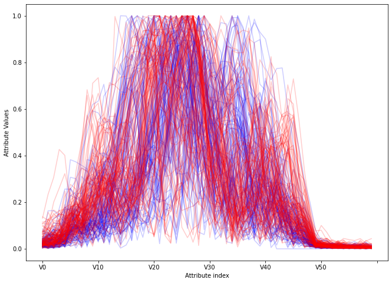

```python
plt.figure(figsize=(11,8))
for i in range(208):
    if rocksVMines.iat[i, 60] == "M":
        pcolor = "red"
    else:
        pcolor = "blue"

    dataRow = rocksVMines.iloc[i, 0:60] # 0~59열의 데이터
    dataRow.plot(color=pcolor, alpha=0.2)


plt.xlabel("Attribute index")
plt.ylabel(("Attribute Values"))
plt.show()
```

### 각 특성(피처, 속성)간의 상호관계는 어떻게 될까?

- 각 속성 간의 상호관계 시각화

```
<class 'pandas.core.series.Series'> <class 'pandas.core.series.Series'>
```

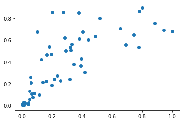

```python
# 2번째 행과 3번째 행의 상호관계 시각화
dat_row2 = rocksVMines.iloc[1,0:60]
dat_row3 = rocksVMines.iloc[2,0:60]

print( type(dat_row2), type(dat_row3) )
plt.scatter(dat_row2, dat_row3)
```

### 실습. 2행과 5행 속성의 상호관계 시각화를 확인해 보자.

### 히트맵을 이용한 상관계수 시각화

```python
dat_corr = rocksVMines.corr()
dat_corr
```

|  | V0 | V1 | V2 | V3 | V4 | V5 | V6 | V7 | V8 | V9 | V10 | V11 | V12 | V13 | V14 | V15 | V16 | V17 | V18 | V19 | V20 | V21 | V22 | V23 | V24 | V25 | V26 | V27 | V28 | … |
| --- | --- | --- | --- | --- | --- | --- | --- | --- | --- | --- | --- | --- | --- | --- | --- | --- | --- | --- | --- | --- | --- | --- | --- | --- | --- | --- | --- | --- | --- | --- |
| V0 | 1.000000 | 0.735896 | 0.571537 | 0.491438 | 0.344797 | 0.238921 | 0.260815 | 0.355523 | 0.353420 | 0.318276 | 0.344058 | 0.210861 | 0.210722 | 0.256278 | 0.304878 | 0.239079 | 0.137845 | 0.041817 | 0.055227 | 0.156760 | 0.117663 | -0.056973 | -0.163426 | -0.218093 | -0.295683 | -0.342865 | -0.341703 | -0.224340 | -0.199099 | … |
| V1 | 0.735896 | 1.000000 | 0.779916 | 0.606684 | 0.419669 | 0.332329 | 0.279040 | 0.334615 | 0.316733 | 0.270782 | 0.297065 | 0.194102 | 0.249596 | 0.273170 | 0.307599 | 0.261844 | 0.152170 | 0.042870 | 0.040911 | 0.102428 | 0.075255 | -0.074157 | -0.179365 | -0.196469 | -0.295302 | -0.365749 | -0.337046 | -0.234386 | -0.228490 | … |
| V2 | 0.571537 | 0.779916 | 1.000000 | 0.781786 | 0.546141 | 0.346275 | 0.190434 | 0.237884 | 0.252691 | 0.219637 | 0.274610 | 0.214807 | 0.258767 | 0.291724 | 0.285663 | 0.237017 | 0.201093 | 0.120587 | 0.099303 | 0.103117 | 0.063990 | -0.026815 | -0.073400 | -0.085380 | -0.214256 | -0.291974 | -0.263111 | -0.256674 | -0.290728 | … |
| V3 | 0.491438 | 0.606684 | 0.781786 | 1.000000 | 0.726943 | 0.352805 | 0.246440 | 0.246742 | 0.247078 | 0.237769 | 0.271881 | 0.175381 | 0.215754 | 0.286708 | 0.278529 | 0.248245 | 0.223203 | 0.194992 | 0.189405 | 0.188317 | 0.142271 | 0.036010 | -0.029749 | -0.102975 | -0.206673 | -0.291357 | -0.294749 | -0.256074 | -0.300476 | … |
| V4 | 0.344797 | 0.419669 | 0.546141 | 0.726943 | 1.000000 | 0.597053 | 0.335422 | 0.204006 | 0.177906 | 0.183219 | 0.231684 | 0.211657 | 0.299086 | 0.359062 | 0.318059 | 0.328725 | 0.326477 | 0.299266 | 0.340543 | 0.285737 | 0.205088 | 0.152897 | 0.073934 | -0.000624 | -0.067296 | -0.125675 | -0.169618 | -0.214692 | -0.283863 | … |
| V5 | 0.238921 | 0.332329 | 0.346275 | 0.352805 | 0.597053 | 1.000000 | 0.702889 | 0.471683 | 0.327578 | 0.288621 | 0.333570 | 0.344451 | 0.411107 | 0.396233 | 0.367908 | 0.353783 | 0.293190 | 0.235778 | 0.226305 | 0.206841 | 0.174768 | 0.123770 | 0.064081 | 0.027026 | -0.043280 | -0.100309 | -0.129094 | -0.118645 | -0.156081 | … |
| V6 | 0.260815 | 0.279040 | 0.190434 | 0.246440 | 0.335422 | 0.702889 | 1.000000 | 0.675774 | 0.470580 | 0.425448 | 0.396588 | 0.274432 | 0.365391 | 0.409576 | 0.411692 | 0.363086 | 0.250024 | 0.208057 | 0.215495 | 0.196496 | 0.165827 | 0.063773 | 0.009359 | 0.011982 | -0.057147 | -0.126074 | -0.179526 | -0.116848 | -0.129694 | … |
| V7 | 0.355523 | 0.334615 | 0.237884 | 0.246742 | 0.204006 | 0.471683 | 0.675774 | 1.000000 | 0.778577 | 0.652525 | 0.584583 | 0.328329 | 0.322951 | 0.387114 | 0.391514 | 0.322237 | 0.140912 | 0.061333 | 0.061825 | 0.204950 | 0.208785 | 0.023786 | -0.092087 | -0.124427 | -0.196354 | -0.203178 | -0.233332 | -0.120343 | -0.139750 | … |
| V8 | 0.353420 | 0.316733 | 0.252691 | 0.247078 | 0.177906 | 0.327578 | 0.470580 | 0.778577 | 1.000000 | 0.877131 | 0.728063 | 0.363404 | 0.316899 | 0.329659 | 0.299575 | 0.241819 | 0.100146 | 0.027380 | 0.067237 | 0.266455 | 0.264109 | 0.019512 | -0.154752 | -0.189343 | -0.198658 | -0.137459 | -0.119143 | -0.028002 | -0.093413 | … |
| V9 | 0.318276 | 0.270782 | 0.219637 | 0.237769 | 0.183219 | 0.288621 | 0.425448 | 0.652525 | 0.877131 | 1.000000 | 0.853140 | 0.485392 | 0.405370 | 0.345684 | 0.294699 | 0.242869 | 0.121264 | 0.063745 | 0.099632 | 0.246924 | 0.240862 | 0.070381 | -0.094887 | -0.178304 | -0.179890 | -0.109051 | -0.095820 | -0.052303 | -0.137173 | … |
| V10 | 0.344058 | 0.297065 | 0.274610 | 0.271881 | 0.231684 | 0.333570 | 0.396588 | 0.584583 | 0.728063 | 0.853140 | 1.000000 | 0.781164 | 0.646978 | 0.460504 | 0.356516 | 0.304069 | 0.237679 | 0.191567 | 0.221669 | 0.315975 | 0.287338 | 0.150078 | -0.007886 | -0.066705 | -0.071493 | -0.066961 | -0.072859 | -0.069156 | -0.147221 | … |
| V11 | 0.210861 | 0.194102 | 0.214807 | 0.175381 | 0.211657 | 0.344451 | 0.274432 | 0.328329 | 0.363404 | 0.485392 | 0.781164 | 1.000000 | 0.827106 | 0.467793 | 0.281758 | 0.245383 | 0.250611 | 0.241910 | 0.258685 | 0.267826 | 0.197051 | 0.108243 | 0.002739 | -0.051297 | -0.048840 | -0.082879 | -0.046687 | -0.058846 | -0.105324 | … |
| V12 | 0.210722 | 0.249596 | 0.258767 | 0.215754 | 0.299086 | 0.411107 | 0.365391 | 0.322951 | 0.316899 | 0.405370 | 0.646978 | 0.827106 | 1.000000 | 0.756758 | 0.530892 | 0.465977 | 0.438185 | 0.394510 | 0.398479 | 0.366260 | 0.261398 | 0.168600 | 0.035288 | -0.058068 | -0.078022 | -0.101443 | -0.090046 | -0.129290 | -0.183920 | … |
| V13 | 0.256278 | 0.273170 | 0.291724 | 0.286708 | 0.359062 | 0.396233 | 0.409576 | 0.387114 | 0.329659 | 0.345684 | 0.460504 | 0.467793 | 0.756758 | 1.000000 | 0.869733 | 0.747277 | 0.636990 | 0.560637 | 0.509763 | 0.461382 | 0.360967 | 0.244916 | 0.092750 | -0.027058 | -0.113588 | -0.157795 | -0.210409 | -0.322235 | -0.357253 | … |
| V14 | 0.304878 | 0.307599 | 0.285663 | 0.278529 | 0.318059 | 0.367908 | 0.411692 | 0.391514 | 0.299575 | 0.294699 | 0.356516 | 0.281758 | 0.530892 | 0.869733 | 1.000000 | 0.912625 | 0.749942 | 0.632139 | 0.546463 | 0.474398 | 0.391010 | 0.258852 | 0.074203 | -0.045193 | -0.161965 | -0.241322 | -0.315958 | -0.412406 | -0.427114 | … |
| V15 | 0.239079 | 0.261844 | 0.237017 | 0.248245 | 0.328725 | 0.353783 | 0.363086 | 0.322237 | 0.241819 | 0.242869 | 0.304069 | 0.245383 | 0.465977 | 0.747277 | 0.912625 | 1.000000 | 0.899234 | 0.774855 | 0.652912 | 0.516351 | 0.427079 | 0.312423 | 0.125501 | -0.017621 | -0.136162 | -0.242903 | -0.326183 | -0.449855 | -0.494690 | … |
| V16 | 0.137845 | 0.152170 | 0.201093 | 0.223203 | 0.326477 | 0.293190 | 0.250024 | 0.140912 | 0.100146 | 0.121264 | 0.237679 | 0.250611 | 0.438185 | 0.636990 | 0.749942 | 0.899234 | 1.000000 | 0.925836 | 0.747220 | 0.525525 | 0.447226 | 0.413374 | 0.248274 | 0.081193 | -0.029039 | -0.177982 | -0.265171 | -0.437899 | -0.488456 | … |
| V17 | 0.041817 | 0.042870 | 0.120587 | 0.194992 | 0.299266 | 0.235778 | 0.208057 | 0.061333 | 0.027380 | 0.063745 | 0.191567 | 0.241910 | 0.394510 | 0.560637 | 0.632139 | 0.774855 | 0.925836 | 1.000000 | 0.875028 | 0.642354 | 0.540894 | 0.502493 | 0.337298 | 0.151078 | 0.024011 | -0.150286 | -0.263858 | -0.459448 | -0.489804 | … |
| V18 | 0.055227 | 0.040911 | 0.099303 | 0.189405 | 0.340543 | 0.226305 | 0.215495 | 0.061825 | 0.067237 | 0.099632 | 0.221669 | 0.258685 | 0.398479 | 0.509763 | 0.546463 | 0.652912 | 0.747220 | 0.875028 | 1.000000 | 0.854572 | 0.710000 | 0.592810 | 0.386863 | 0.183889 | 0.026377 | -0.122884 | -0.232950 | -0.419546 | -0.454639 | … |
| V19 | 0.156760 | 0.102428 | 0.103117 | 0.188317 | 0.285737 | 0.206841 | 0.196496 | 0.204950 | 0.266455 | 0.246924 | 0.315975 | 0.267826 | 0.366260 | 0.461382 | 0.474398 | 0.516351 | 0.525525 | 0.642354 | 0.854572 | 1.000000 | 0.905062 | 0.649279 | 0.354996 | 0.131925 | -0.009331 | -0.095179 | -0.205906 | -0.354795 | -0.428887 | … |
| V20 | 0.117663 | 0.075255 | 0.063990 | 0.142271 | 0.205088 | 0.174768 | 0.165827 | 0.208785 | 0.264109 | 0.240862 | 0.287338 | 0.197051 | 0.261398 | 0.360967 | 0.391010 | 0.427079 | 0.447226 | 0.540894 | 0.710000 | 0.905062 | 1.000000 | 0.805219 | 0.467438 | 0.253407 | 0.119919 | 0.029066 | -0.103393 | -0.274077 | -0.379599 | … |
| V21 | -0.056973 | -0.074157 | -0.026815 | 0.036010 | 0.152897 | 0.123770 | 0.063773 | 0.023786 | 0.019512 | 0.070381 | 0.150078 | 0.108243 | 0.168600 | 0.244916 | 0.258852 | 0.312423 | 0.413374 | 0.502493 | 0.592810 | 0.649279 | 0.805219 | 1.000000 | 0.834073 | 0.585010 | 0.426029 | 0.286921 | 0.139726 | -0.133444 | -0.268667 | … |
| V22 | -0.163426 | -0.179365 | -0.073400 | -0.029749 | 0.073934 | 0.064081 | 0.009359 | -0.092087 | -0.154752 | -0.094887 | -0.007886 | 0.002739 | 0.035288 | 0.092750 | 0.074203 | 0.125501 | 0.248274 | 0.337298 | 0.386863 | 0.354996 | 0.467438 | 0.834073 | 1.000000 | 0.850294 | 0.624911 | 0.432209 | 0.302970 | 0.035464 | -0.121061 | … |
| V23 | -0.218093 | -0.196469 | -0.085380 | -0.102975 | -0.000624 | 0.027026 | 0.011982 | -0.124427 | -0.189343 | -0.178304 | -0.066705 | -0.051297 | -0.058068 | -0.027058 | -0.045193 | -0.017621 | 0.081193 | 0.151078 | 0.183889 | 0.131925 | 0.253407 | 0.585010 | 0.850294 | 1.000000 | 0.853140 | 0.597442 | 0.438902 | 0.200807 | 0.047326 | … |
| V24 | -0.295683 | -0.295302 | -0.214256 | -0.206673 | -0.067296 | -0.043280 | -0.057147 | -0.196354 | -0.198658 | -0.179890 | -0.071493 | -0.048840 | -0.078022 | -0.113588 | -0.161965 | -0.136162 | -0.029039 | 0.024011 | 0.026377 | -0.009331 | 0.119919 | 0.426029 | 0.624911 | 0.853140 | 1.000000 | 0.845997 | 0.625134 | 0.358819 | 0.168013 | … |
| V25 | -0.342865 | -0.365749 | -0.291974 | -0.291357 | -0.125675 | -0.100309 | -0.126074 | -0.203178 | -0.137459 | -0.109051 | -0.066961 | -0.082879 | -0.101443 | -0.157795 | -0.241322 | -0.242903 | -0.177982 | -0.150286 | -0.122884 | -0.095179 | 0.029066 | 0.286921 | 0.432209 | 0.597442 | 0.845997 | 1.000000 | 0.857242 | 0.531667 | 0.278099 | … |
| V26 | -0.341703 | -0.337046 | -0.263111 | -0.294749 | -0.169618 | -0.129094 | -0.179526 | -0.233332 | -0.119143 | -0.095820 | -0.072859 | -0.046687 | -0.090046 | -0.210409 | -0.315958 | -0.326183 | -0.265171 | -0.263858 | -0.232950 | -0.205906 | -0.103393 | 0.139726 | 0.302970 | 0.438902 | 0.625134 | 0.857242 | 1.000000 | 0.791948 | 0.464730 | … |
| V27 | -0.224340 | -0.234386 | -0.256674 | -0.256074 | -0.214692 | -0.118645 | -0.116848 | -0.120343 | -0.028002 | -0.052303 | -0.069156 | -0.058846 | -0.129290 | -0.322235 | -0.412406 | -0.449855 | -0.437899 | -0.459448 | -0.419546 | -0.354795 | -0.274077 | -0.133444 | 0.035464 | 0.200807 | 0.358819 | 0.531667 | 0.791948 | 1.000000 | 0.814894 | … |
| V28 | -0.199099 | -0.228490 | -0.290728 | -0.300476 | -0.283863 | -0.156081 | -0.129694 | -0.139750 | -0.093413 | -0.137173 | -0.147221 | -0.105324 | -0.183920 | -0.357253 | -0.427114 | -0.494690 | -0.488456 | -0.489804 | -0.454639 | -0.428887 | -0.379599 | -0.268667 | -0.121061 | 0.047326 | 0.168013 | 0.278099 | 0.464730 | 0.814894 | 1.000000 | … |
| V29 | -0.077430 | -0.115301 | -0.197493 | -0.236602 | -0.273350 | -0.151186 | -0.068142 | -0.017654 | 0.053398 | -0.043998 | -0.134092 | -0.177031 | -0.254774 | -0.342446 | -0.350321 | -0.400206 | -0.427261 | -0.466110 | -0.462054 | -0.428063 | -0.406164 | -0.351940 | -0.261888 | -0.140217 | -0.032932 | 0.080306 | 0.214771 | 0.542061 | 0.811801 | … |
| V30 | -0.048370 | -0.055862 | -0.106198 | -0.190086 | -0.214336 | -0.054136 | -0.096945 | -0.081072 | -0.041649 | -0.091193 | -0.154080 | -0.102913 | -0.183534 | -0.294995 | -0.329028 | -0.352513 | -0.342982 | -0.400695 | -0.473748 | -0.527215 | -0.531777 | -0.388758 | -0.231854 | -0.119447 | -0.032503 | 0.021253 | 0.138621 | 0.377704 | 0.556035 | … |
| V31 | -0.030444 | -0.049683 | -0.109895 | -0.169987 | -0.173485 | -0.051934 | -0.115871 | -0.108115 | -0.028629 | -0.058493 | -0.121932 | -0.050670 | -0.140976 | -0.309892 | -0.385266 | -0.366060 | -0.326759 | -0.364153 | -0.419634 | -0.424650 | -0.448321 | -0.349628 | -0.211934 | -0.139220 | -0.053342 | -0.016172 | 0.058847 | 0.258699 | 0.358832 | … |
| V32 | -0.031939 | -0.108272 | -0.170671 | -0.164651 | -0.200586 | -0.144391 | -0.127052 | -0.087246 | -0.017885 | -0.027245 | -0.125731 | -0.124675 | -0.217275 | -0.360801 | -0.425188 | -0.415943 | -0.388972 | -0.369683 | -0.374371 | -0.332683 | -0.379134 | -0.380157 | -0.290609 | -0.248524 | -0.190662 | -0.155395 | -0.148464 | 0.059350 | 0.264561 | … |
| V33 | 0.031319 | -0.004247 | -0.099409 | -0.083965 | -0.140559 | -0.070337 | -0.077662 | -0.014578 | 0.013594 | -0.021291 | -0.120645 | -0.148579 | -0.255059 | -0.348018 | -0.343971 | -0.330425 | -0.334546 | -0.328220 | -0.301340 | -0.217885 | -0.271558 | -0.376646 | -0.351211 | -0.327284 | -0.299620 | -0.282663 | -0.298064 | -0.085737 | 0.131560 | … |
| V34 | 0.098118 | 0.115824 | 0.017053 | 0.015200 | -0.086529 | -0.028815 | -0.015531 | 0.035733 | 0.015065 | -0.035765 | -0.162117 | -0.248430 | -0.316324 | -0.314983 | -0.241706 | -0.199220 | -0.209048 | -0.245045 | -0.283749 | -0.244713 | -0.262600 | -0.356308 | -0.351840 | -0.325294 | -0.301712 | -0.295141 | -0.292251 | -0.116153 | 0.013167 | … |
| V35 | 0.080722 | 0.132611 | 0.053070 | 0.039282 | -0.073481 | -0.023621 | 0.002979 | 0.087187 | 0.036120 | -0.004460 | -0.135543 | -0.232932 | -0.284109 | -0.274913 | -0.214028 | -0.163630 | -0.177765 | -0.220698 | -0.296833 | -0.262485 | -0.269318 | -0.331623 | -0.316092 | -0.289771 | -0.289522 | -0.278229 | -0.255183 | -0.127967 | -0.039257 | … |
| V36 | 0.119565 | 0.169186 | 0.107530 | 0.063486 | -0.064617 | -0.064798 | -0.001376 | 0.110739 | 0.111769 | 0.085072 | -0.057248 | -0.149604 | -0.235742 | -0.219570 | -0.150925 | -0.097100 | -0.107869 | -0.149798 | -0.224710 | -0.185972 | -0.203849 | -0.293628 | -0.323255 | -0.314087 | -0.316165 | -0.285887 | -0.221706 | -0.127925 | -0.079858 | … |
| V37 | 0.209873 | 0.217494 | 0.130276 | 0.089887 | -0.008620 | -0.048745 | 0.065900 | 0.186609 | 0.223983 | 0.175717 | 0.009732 | -0.071704 | -0.151781 | -0.162695 | -0.139160 | -0.104660 | -0.148144 | -0.170696 | -0.176935 | -0.089038 | -0.125157 | -0.314274 | -0.414772 | -0.444269 | -0.453614 | -0.382419 | -0.292864 | -0.135408 | -0.085254 | … |
| V38 | 0.208371 | 0.186828 | 0.110499 | 0.089346 | 0.063408 | 0.030599 | 0.080942 | 0.206145 | 0.211897 | 0.233833 | 0.116225 | 0.070055 | -0.009362 | -0.077266 | -0.131518 | -0.133001 | -0.211470 | -0.205616 | -0.141508 | -0.040307 | -0.091454 | -0.308325 | -0.401100 | -0.442243 | -0.441063 | -0.351400 | -0.297673 | -0.142289 | -0.080647 | … |
| V39 | 0.099993 | 0.098350 | 0.074137 | 0.045141 | 0.061616 | 0.081119 | 0.112673 | 0.184411 | 0.122735 | 0.177357 | 0.066532 | 0.055238 | -0.027754 | -0.072441 | -0.122034 | -0.120267 | -0.187656 | -0.167345 | -0.150185 | -0.125857 | -0.157652 | -0.270545 | -0.298365 | -0.330924 | -0.351496 | -0.304974 | -0.293454 | -0.215574 | -0.130569 | … |
| V40 | 0.127313 | 0.188226 | 0.189047 | 0.145241 | 0.098832 | 0.075797 | 0.041071 | 0.097517 | 0.019589 | -0.002523 | -0.080723 | -0.030371 | -0.068478 | -0.089120 | -0.107464 | -0.101144 | -0.145595 | -0.188249 | -0.224330 | -0.261167 | -0.270653 | -0.281911 | -0.247471 | -0.268708 | -0.296955 | -0.313669 | -0.300502 | -0.204079 | -0.092596 | … |
| V41 | 0.213592 | 0.261345 | 0.233442 | 0.144693 | 0.125181 | 0.048763 | -0.028720 | 0.076054 | -0.005785 | -0.018880 | -0.011556 | 0.072670 | 0.040461 | -0.040482 | -0.105692 | -0.143167 | -0.176052 | -0.232927 | -0.231430 | -0.237317 | -0.254223 | -0.263698 | -0.220959 | -0.219990 | -0.222729 | -0.217527 | -0.180693 | -0.088138 | 0.006362 | … |
| V42 | 0.206057 | 0.186368 | 0.113920 | 0.050629 | 0.063706 | 0.034380 | -0.025727 | 0.114721 | 0.052409 | 0.076138 | 0.101743 | 0.160656 | 0.082965 | -0.072432 | -0.186529 | -0.220929 | -0.257145 | -0.301094 | -0.265565 | -0.248134 | -0.213933 | -0.188785 | -0.153685 | -0.150371 | -0.119290 | -0.064184 | -0.019041 | 0.066173 | 0.108470 | … |
| V43 | 0.157949 | 0.133018 | 0.071946 | -0.008407 | 0.031575 | 0.048870 | 0.061404 | 0.135426 | 0.215710 | 0.216742 | 0.185591 | 0.154133 | 0.084226 | -0.077124 | -0.182203 | -0.175102 | -0.206424 | -0.272986 | -0.205319 | -0.168049 | -0.137647 | -0.136376 | -0.156661 | -0.120932 | -0.054302 | 0.007166 | 0.042174 | 0.133443 | 0.157058 | … |
| V44 | 0.279968 | 0.285716 | 0.180734 | 0.087824 | 0.089202 | 0.085468 | 0.110813 | 0.240176 | 0.320573 | 0.287459 | 0.220705 | 0.123762 | 0.091938 | -0.018240 | -0.087725 | -0.103235 | -0.185405 | -0.303956 | -0.221794 | -0.109220 | -0.092053 | -0.147650 | -0.224421 | -0.211755 | -0.152676 | -0.071331 | -0.027800 | 0.100732 | 0.134740 | … |
| V45 | 0.319354 | 0.304247 | 0.173649 | 0.080012 | 0.081964 | 0.029524 | 0.076537 | 0.169099 | 0.195447 | 0.138447 | 0.077971 | 0.023391 | 0.016202 | -0.051486 | -0.090647 | -0.112658 | -0.193676 | -0.311369 | -0.239128 | -0.165945 | -0.163086 | -0.180775 | -0.212862 | -0.200788 | -0.145932 | -0.093775 | -0.079800 | 0.064185 | 0.140317 | … |
| V46 | 0.230343 | 0.255797 | 0.179528 | 0.046109 | 0.041419 | 0.016640 | 0.098925 | 0.109744 | 0.084191 | 0.090662 | 0.038045 | 0.022328 | 0.015964 | -0.040289 | -0.066069 | -0.099055 | -0.158920 | -0.241793 | -0.197197 | -0.215006 | -0.204393 | -0.146962 | -0.136550 | -0.131755 | -0.108048 | -0.116090 | -0.082842 | 0.063410 | 0.163451 | … |
| V47 | 0.203234 | 0.265279 | 0.234896 | 0.121065 | 0.084435 | 0.067196 | 0.155221 | 0.222783 | 0.225667 | 0.268123 | 0.185728 | 0.084092 | 0.076681 | 0.026812 | -0.045011 | -0.075944 | -0.141254 | -0.220355 | -0.206018 | -0.210898 | -0.187869 | -0.197029 | -0.207166 | -0.178896 | -0.157434 | -0.138438 | -0.098290 | 0.054759 | 0.131138 | … |
| V48 | 0.247560 | 0.313995 | 0.223074 | 0.133294 | 0.088128 | 0.080729 | 0.194720 | 0.271422 | 0.222135 | 0.264885 | 0.197313 | 0.103959 | 0.101629 | 0.074154 | 0.015169 | -0.008300 | -0.077968 | -0.153307 | -0.136021 | -0.138967 | -0.104631 | -0.117165 | -0.128346 | -0.131604 | -0.160468 | -0.159770 | -0.128580 | -0.000153 | 0.051365 | … |
| V49 | 0.269287 | 0.245868 | 0.081096 | 0.077925 | 0.066751 | 0.017300 | 0.166112 | 0.191615 | 0.150527 | 0.162010 | 0.047535 | 0.008992 | 0.058744 | 0.062499 | 0.028431 | 0.032618 | -0.032438 | -0.076009 | -0.041046 | -0.005680 | -0.003260 | -0.034615 | -0.092958 | -0.186477 | -0.207578 | -0.197763 | -0.185739 | -0.075826 | -0.035241 | … |
| V50 | 0.254450 | 0.320538 | 0.238110 | 0.174676 | 0.115936 | 0.171767 | 0.184152 | 0.260692 | 0.174873 | 0.167096 | 0.157615 | 0.113418 | 0.203347 | 0.180464 | 0.153162 | 0.099892 | 0.009036 | -0.104656 | -0.050988 | -0.022960 | -0.024222 | -0.061054 | -0.108172 | -0.143650 | -0.200752 | -0.191554 | -0.137886 | -0.027750 | -0.000251 | … |
| V51 | 0.355299 | 0.434548 | 0.394076 | 0.374651 | 0.266617 | 0.252288 | 0.144051 | 0.219038 | 0.207996 | 0.165537 | 0.165748 | 0.117699 | 0.147479 | 0.137443 | 0.135271 | 0.104039 | 0.020313 | -0.057236 | 0.011450 | 0.028754 | -0.034845 | -0.092204 | -0.108934 | -0.175022 | -0.250479 | -0.256166 | -0.191707 | -0.064730 | -0.054779 | … |
| V52 | 0.311729 | 0.346076 | 0.332914 | 0.364772 | 0.314985 | 0.162404 | 0.046403 | 0.102447 | 0.105352 | 0.097544 | 0.084801 | 0.042263 | 0.058599 | 0.133196 | 0.103444 | 0.096325 | 0.035635 | -0.006627 | 0.051367 | 0.069692 | -0.000270 | -0.094203 | -0.152691 | -0.225897 | -0.238478 | -0.248400 | -0.259825 | -0.148791 | -0.130527 | … |
| V53 | 0.322299 | 0.383960 | 0.367186 | 0.334211 | 0.205306 | 0.164073 | 0.163074 | 0.234008 | 0.202615 | 0.146725 | 0.142572 | 0.078457 | 0.160916 | 0.210925 | 0.218703 | 0.206922 | 0.129138 | 0.072344 | 0.120153 | 0.171936 | 0.167327 | 0.045224 | -0.055641 | -0.125419 | -0.219817 | -0.277169 | -0.269558 | -0.213300 | -0.235110 | … |
| V54 | 0.312067 | 0.380165 | 0.289731 | 0.284955 | 0.196472 | 0.133464 | 0.195541 | 0.239551 | 0.179342 | 0.175254 | 0.228991 | 0.164590 | 0.272492 | 0.326821 | 0.261822 | 0.240968 | 0.168460 | 0.093767 | 0.099082 | 0.157272 | 0.059823 | -0.119720 | -0.198577 | -0.229297 | -0.276419 | -0.353657 | -0.347931 | -0.262620 | -0.246181 | … |
| V55 | 0.220642 | 0.262263 | 0.287661 | 0.280938 | 0.199323 | 0.166758 | 0.174143 | 0.276819 | 0.232764 | 0.151889 | 0.122332 | 0.115658 | 0.183743 | 0.252166 | 0.218395 | 0.215478 | 0.128968 | 0.080812 | 0.121331 | 0.178498 | 0.139089 | -0.030877 | -0.138900 | -0.178320 | -0.187789 | -0.215894 | -0.263403 | -0.198093 | -0.221273 | … |
| V56 | 0.313725 | 0.280341 | 0.380819 | 0.340254 | 0.219395 | 0.161333 | 0.186324 | 0.267212 | 0.193963 | 0.140327 | 0.103405 | 0.030732 | 0.057870 | 0.190886 | 0.202511 | 0.191736 | 0.145708 | 0.056930 | 0.045204 | 0.066425 | 0.030943 | -0.069909 | -0.098291 | -0.117429 | -0.157967 | -0.254240 | -0.267069 | -0.190854 | -0.228155 | … |
| V57 | 0.368132 | 0.353042 | 0.334108 | 0.344865 | 0.238793 | 0.203986 | 0.242646 | 0.287603 | 0.231745 | 0.212277 | 0.193358 | 0.065273 | 0.171140 | 0.258675 | 0.225545 | 0.198019 | 0.148563 | 0.096022 | 0.138365 | 0.132453 | 0.079818 | -0.035829 | -0.105235 | -0.210556 | -0.270222 | -0.303427 | -0.321868 | -0.261443 | -0.267938 | … |
| V58 | 0.357116 | 0.352200 | 0.425047 | 0.420266 | 0.290982 | 0.220573 | 0.183578 | 0.194400 | 0.097293 | 0.058273 | 0.067726 | 0.044614 | 0.151804 | 0.209122 | 0.193671 | 0.182337 | 0.121800 | 0.028446 | 0.023019 | -0.005364 | -0.049413 | -0.143209 | -0.168149 | -0.186527 | -0.303155 | -0.385725 | -0.360340 | -0.275442 | -0.247318 | … |
| V59 | 0.347078 | 0.358761 | 0.373948 | 0.400626 | 0.253710 | 0.178158 | 0.222493 | 0.146216 | 0.095243 | 0.097358 | 0.089695 | 0.071364 | 0.061411 | 0.120966 | 0.171089 | 0.158438 | 0.093992 | 0.046617 | 0.007468 | -0.028540 | -0.025201 | -0.085696 | -0.163696 | -0.190877 | -0.253233 | -0.303949 | -0.267596 | -0.195130 | -0.203776 | … |

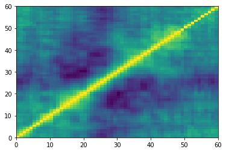

```python
plt.pcolor(dat_corr)
plt.show()
```

```python
import seaborn as sns
```

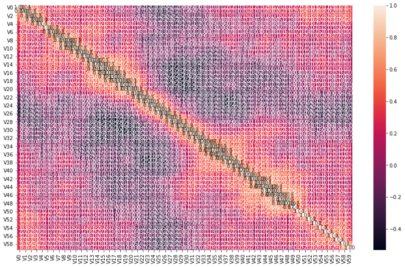

```python
plt.figure(figsize=(15,9))
sns.heatmap(dat_corr, annot=True, fmt='.2f', )
plt.show()
```

```python
### 첫번째에서 20번째 속성에 대한 상관관계를 확읺
```

```python
dat20_corr = rocksVMines.iloc[:,0:20].corr()
dat20_corr
```

|  | V0 | V1 | V2 | V3 | V4 | V5 | V6 | V7 | V8 | V9 | V10 | V11 | V12 | V13 | V14 | V15 | V16 | V17 | V18 | V19 |
| --- | --- | --- | --- | --- | --- | --- | --- | --- | --- | --- | --- | --- | --- | --- | --- | --- | --- | --- | --- | --- |
| V0 | 1.000000 | 0.735896 | 0.571537 | 0.491438 | 0.344797 | 0.238921 | 0.260815 | 0.355523 | 0.353420 | 0.318276 | 0.344058 | 0.210861 | 0.210722 | 0.256278 | 0.304878 | 0.239079 | 0.137845 | 0.041817 | 0.055227 | 0.156760 |
| V1 | 0.735896 | 1.000000 | 0.779916 | 0.606684 | 0.419669 | 0.332329 | 0.279040 | 0.334615 | 0.316733 | 0.270782 | 0.297065 | 0.194102 | 0.249596 | 0.273170 | 0.307599 | 0.261844 | 0.152170 | 0.042870 | 0.040911 | 0.102428 |
| V2 | 0.571537 | 0.779916 | 1.000000 | 0.781786 | 0.546141 | 0.346275 | 0.190434 | 0.237884 | 0.252691 | 0.219637 | 0.274610 | 0.214807 | 0.258767 | 0.291724 | 0.285663 | 0.237017 | 0.201093 | 0.120587 | 0.099303 | 0.103117 |
| V3 | 0.491438 | 0.606684 | 0.781786 | 1.000000 | 0.726943 | 0.352805 | 0.246440 | 0.246742 | 0.247078 | 0.237769 | 0.271881 | 0.175381 | 0.215754 | 0.286708 | 0.278529 | 0.248245 | 0.223203 | 0.194992 | 0.189405 | 0.188317 |
| V4 | 0.344797 | 0.419669 | 0.546141 | 0.726943 | 1.000000 | 0.597053 | 0.335422 | 0.204006 | 0.177906 | 0.183219 | 0.231684 | 0.211657 | 0.299086 | 0.359062 | 0.318059 | 0.328725 | 0.326477 | 0.299266 | 0.340543 | 0.285737 |
| V5 | 0.238921 | 0.332329 | 0.346275 | 0.352805 | 0.597053 | 1.000000 | 0.702889 | 0.471683 | 0.327578 | 0.288621 | 0.333570 | 0.344451 | 0.411107 | 0.396233 | 0.367908 | 0.353783 | 0.293190 | 0.235778 | 0.226305 | 0.206841 |
| V6 | 0.260815 | 0.279040 | 0.190434 | 0.246440 | 0.335422 | 0.702889 | 1.000000 | 0.675774 | 0.470580 | 0.425448 | 0.396588 | 0.274432 | 0.365391 | 0.409576 | 0.411692 | 0.363086 | 0.250024 | 0.208057 | 0.215495 | 0.196496 |
| V7 | 0.355523 | 0.334615 | 0.237884 | 0.246742 | 0.204006 | 0.471683 | 0.675774 | 1.000000 | 0.778577 | 0.652525 | 0.584583 | 0.328329 | 0.322951 | 0.387114 | 0.391514 | 0.322237 | 0.140912 | 0.061333 | 0.061825 | 0.204950 |
| V8 | 0.353420 | 0.316733 | 0.252691 | 0.247078 | 0.177906 | 0.327578 | 0.470580 | 0.778577 | 1.000000 | 0.877131 | 0.728063 | 0.363404 | 0.316899 | 0.329659 | 0.299575 | 0.241819 | 0.100146 | 0.027380 | 0.067237 | 0.266455 |
| V9 | 0.318276 | 0.270782 | 0.219637 | 0.237769 | 0.183219 | 0.288621 | 0.425448 | 0.652525 | 0.877131 | 1.000000 | 0.853140 | 0.485392 | 0.405370 | 0.345684 | 0.294699 | 0.242869 | 0.121264 | 0.063745 | 0.099632 | 0.246924 |
| V10 | 0.344058 | 0.297065 | 0.274610 | 0.271881 | 0.231684 | 0.333570 | 0.396588 | 0.584583 | 0.728063 | 0.853140 | 1.000000 | 0.781164 | 0.646978 | 0.460504 | 0.356516 | 0.304069 | 0.237679 | 0.191567 | 0.221669 | 0.315975 |
| V11 | 0.210861 | 0.194102 | 0.214807 | 0.175381 | 0.211657 | 0.344451 | 0.274432 | 0.328329 | 0.363404 | 0.485392 | 0.781164 | 1.000000 | 0.827106 | 0.467793 | 0.281758 | 0.245383 | 0.250611 | 0.241910 | 0.258685 | 0.267826 |
| V12 | 0.210722 | 0.249596 | 0.258767 | 0.215754 | 0.299086 | 0.411107 | 0.365391 | 0.322951 | 0.316899 | 0.405370 | 0.646978 | 0.827106 | 1.000000 | 0.756758 | 0.530892 | 0.465977 | 0.438185 | 0.394510 | 0.398479 | 0.366260 |
| V13 | 0.256278 | 0.273170 | 0.291724 | 0.286708 | 0.359062 | 0.396233 | 0.409576 | 0.387114 | 0.329659 | 0.345684 | 0.460504 | 0.467793 | 0.756758 | 1.000000 | 0.869733 | 0.747277 | 0.636990 | 0.560637 | 0.509763 | 0.461382 |
| V14 | 0.304878 | 0.307599 | 0.285663 | 0.278529 | 0.318059 | 0.367908 | 0.411692 | 0.391514 | 0.299575 | 0.294699 | 0.356516 | 0.281758 | 0.530892 | 0.869733 | 1.000000 | 0.912625 | 0.749942 | 0.632139 | 0.546463 | 0.474398 |
| V15 | 0.239079 | 0.261844 | 0.237017 | 0.248245 | 0.328725 | 0.353783 | 0.363086 | 0.322237 | 0.241819 | 0.242869 | 0.304069 | 0.245383 | 0.465977 | 0.747277 | 0.912625 | 1.000000 | 0.899234 | 0.774855 | 0.652912 | 0.516351 |
| V16 | 0.137845 | 0.152170 | 0.201093 | 0.223203 | 0.326477 | 0.293190 | 0.250024 | 0.140912 | 0.100146 | 0.121264 | 0.237679 | 0.250611 | 0.438185 | 0.636990 | 0.749942 | 0.899234 | 1.000000 | 0.925836 | 0.747220 | 0.525525 |
| V17 | 0.041817 | 0.042870 | 0.120587 | 0.194992 | 0.299266 | 0.235778 | 0.208057 | 0.061333 | 0.027380 | 0.063745 | 0.191567 | 0.241910 | 0.394510 | 0.560637 | 0.632139 | 0.774855 | 0.925836 | 1.000000 | 0.875028 | 0.642354 |
| V18 | 0.055227 | 0.040911 | 0.099303 | 0.189405 | 0.340543 | 0.226305 | 0.215495 | 0.061825 | 0.067237 | 0.099632 | 0.221669 | 0.258685 | 0.398479 | 0.509763 | 0.546463 | 0.652912 | 0.747220 | 0.875028 | 1.000000 | 0.854572 |
| V19 | 0.156760 | 0.102428 | 0.103117 | 0.188317 | 0.285737 | 0.206841 | 0.196496 | 0.204950 | 0.266455 | 0.246924 | 0.315975 | 0.267826 | 0.366260 | 0.461382 | 0.474398 | 0.516351 | 0.525525 | 0.642354 | 0.854572 | 1.000000 |